# Proyecto Final: Aplicaciones y Casos de Uso Empresarial

## Diseño de la campaña de incentivos.

Los principales grupos para generar incentivos son el primero grupo de deserotes y no desertores, ya que tienen las mismas características. Esto puede denotar que el grupo de no desertores con estas caractersísticas está al borde de pasar o al grupo 1 de desertores o al grupo 2 o 3 de no desertores. Por ello, hay que intentar que el grupo de no desertores no pase al grupo de desertores. Algunos incentivos que se le pueden ofrecer son:

- **Ofertas a cambio de permanencia**: Se pueden ofrecer productos a precios muy bajos a cambio de diferentes tipos de permanencia. Por ejemplo, un móvil a 0 euros a cambio de una permanencia de 24 meses.
- **Descuentos en el contrato**: Se pueden ofrecer descuentos en el contrato a cambio de una permanencia. Por ejemplo, un 20% de descuento en un contrato anual en comparación con el 0% del contrato mensual.
- **Descuentos en el soporte técnico**: Se pueden ofrecer descuentos en el soporte técnico.

Ahora vamos a pasar a los otros grupos. Estos otros grupos tienen la característica de haber estado mucho tiempo en Movistar, con contratos anuales o bianuales e incluso teniendo soporte técnico. Sin embargo, seguramente atraídos por las ofertas de otras empresas o un reciente descontento con la empresa, están pensando en desertar, conviertiéndose así en el segundo grupo de desertores. Podrían avisar de esto cambiando a contratos mensuales o incluso cancelando directamente los servicios de Movistar. Algunos incentivos que se le pueden ofrecer son:

- **Regalos a cambio de la gran permanencia que tienen:** Se les puede ofrecer un regalo (ya sea un descuento en productos, regalo de meses en un servicio, etc) debido a la gran permanencia que tienen. Por ejemplo, 6 meses de servicio técnico gratuito al cumplir 40 meses de permanencia.
- **Descuentos en el contrato**: Se les puede ofrecer descuentos en el contrato bianual al llevar una buena cantidad de años con este contrato. También se les puede ofrecer a las personas con contrato anual descuentos para incentivar el contrato bianual.
- **Partes gratuitas en el servicio técnico**: A los usuarios con un gran tiempo con servicio técnico se les puede ofrecer partes gratuitas de este servicio. Por ejemplo, en la reparación de un router de menos de “X” años, se les puede ofrecer una parte gratuita de la reparación.

Vamos a ver cómo simular el resultado de estas campañas. El flujo de clientes después de una campaña sería el siguiente:

1. Tenemos unos clientes iniciales (dataset actual)
2. Se incorporan nuevos clientes a la empresa. Estos pertenecerían al grupo 1 de no desertores.
3. Se realiza un movimiento de clientes entre los grupos de no desertores.
4. Se realiza una fuga de clientes al grupo de desertores con unas nuevas probabiliadades debidas a la campaña.

Vamos a dar valores a las probabilidades iniciales. Estos valores no son reales y son simplemente de demostración para la simulación.
$$P(t_0; B_1 \rightarrow A_1) = 0.15 \\
P(t_0; B_1 \rightarrow B_2) = 0.00 \\
P(t_0; B_2 \rightarrow A_2) = 0.10 \\
P(t_0; B_2 \rightarrow B_3) = 0.00 \\
P(t_0; B_3 \rightarrow A_2) = 0.05$$

Ahora, vamos a proponer nuevas probabilidades dentro de unos márgenes de mejora modestos:
$$P(t_1; B_1 \rightarrow A_1) = 0.13 \\
P(t_1; B_1 \rightarrow B_2) = 0.02 \\
P(t_1; B_2 \rightarrow A_2) = 0.05 \\
P(t_1; B_2 \rightarrow B_3) = 0.05 \\
P(t_1; B_3 \rightarrow A_2) = 0.01$$

Ahora que tenemos el método de simulación y los valores necesarios, vamos a crear un dataset que guarde el número de clientes antes y después (con y sin campaña). También creamos un dataset para guardar las probabiliadades con y sin campaña.

```r
# Creamos un dataset con los clientes antiguos y los nuevos
clientes <- data.frame(
    "A1" = c(0, 0, 0),
    "A2" = c(0, 0, 0),
    "B1" = c(0, 0, 0),
    "B2" = c(0, 0, 0),
    "B3" = c(0, 0, 0)
)
rownames(clientes) <- c("antes", "después (con campaña)", "después (sin campaña)")

# Introducimos los datos antiguos
clientes$A1[1] <- nrow(data.churn.noscaled[data.churn.noscaled$cluster == 1, ])
clientes$A2[1] <- nrow(data.churn.noscaled[data.churn.noscaled$cluster == 2, ])
clientes$B1[1] <- nrow(data.nochurn.noscaled[data.nochurn.noscaled$cluster == 1, ])
clientes$B2[1] <- nrow(data.nochurn.noscaled[data.nochurn.noscaled$cluster == 2, ])
clientes$B3[1] <- nrow(data.nochurn.noscaled[data.nochurn.noscaled$cluster == 3, ])

# Vemos el dataset
clientes
```

```
##                         A1  A2   B1   B2   B3
## antes                 1538 331 1643 2285 1246
## después (con campaña)    0   0    0    0    0
## después (sin campaña)    0   0    0    0    0
```

```r
# Creamos un dataset con las probabilidades de flujo
probs <- data.frame(
    "B1toA1" = c(0, 0),
    "B1toB2" = c(0, 0),
    "B2toA2" = c(0, 0),
    "B2toB3" = c(0, 0),
    "B3toA2" = c(0, 0)
)
rownames(probs) <- c("sin campaña", "con campaña")

# Introducimos los datos
probs$B1toA1 <- c(0.15, 0.13)
probs$B1toB2 <- c(0.00, 0.02)
probs$B2toA2 <- c(0.10, 0.05)
probs$B2toB3 <- c(0.00, 0.05)
probs$B3toA2 <- c(0.05, 0.01)

# Definimos el porcentaje de flujo inicial
prob.initial <- 0.20
```

Ahora que tenemos los datos, vamos a simular el flujo de clientes. Supondremos un aumento inicial de los clientes de un 20%.

```r
# Flujos con campaña
clientes$B1[2] <- clientes$B1[1] + (clientes$B1[1] * prob.initial) * (1 - probs$B1toA1[2] - probs$B1toB2[2])
clientes$B2[2] <- clientes$B2[1] * (1 - probs$B2toA2[2] - probs$B2toB3[2]) + clientes$B1[1] * probs$B1toB2[2]
clientes$B3[2] <- clientes$B3[1] * (1 - probs$B3toA2[2]) + clientes$B2[1] * probs$B2toB3[2]
clientes$A1[2] <- clientes$A1[1] + clientes$B1[1] * probs$B1toA1[2]
clientes$A2[2] <- clientes$A2[1] + clientes$B2[1] * probs$B2toA2[2] + clientes$B3[1] * probs$B3toA2[2]

# Flujos sin campaña
clientes$B1[3] <- clientes$B1[1] + (clientes$B1[1] * prob.initial) * (1 - probs$B1toA1[1] - probs$B1toB2[1])
clientes$B2[3] <- clientes$B2[1] * (1 - probs$B2toA2[1] - probs$B2toB3[1]) + clientes$B1[1] * probs$B1toB2[1]
clientes$B3[3] <- clientes$B3[1] * (1 - probs$B3toA2[1]) + clientes$B2[1] * probs$B2toB3[1]
clientes$A1[3] <- clientes$A1[1] + clientes$B1[1] * probs$B1toA1[1]
clientes$A2[3] <- clientes$A2[1] + clientes$B2[1] * probs$B2toA2[1] + clientes$B3[1] * probs$B3toA2[1]

# Truncamos los valores del dataset a números enteros con la función suelo
clientes <- floor(clientes)

# Vemos el dataset
clientes
```

```
##                         A1  A2   B1   B2   B3
## antes                 1538 331 1643 2285 1246
## después (con campaña) 1751 457 1922 2089 1347
## después (sin campaña) 1784 621 1922 2056 1183
```

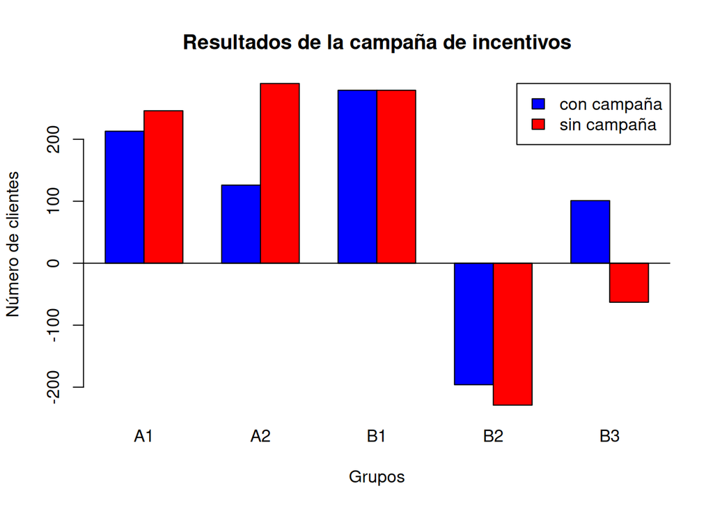

```r
# Para visualizar mejor creamos un dataset que contenga dos filas, una con los datos despues de la campaña menos los de antes y otro con los valores sin campaña menos los de antes
clientes.simulacion <- data.frame(
    "A1" = c(clientes$A1[2] - clientes$A1[1], clientes$A1[3] - clientes$A1[1]),
    "A2" = c(clientes$A2[2] - clientes$A2[1], clientes$A2[3] - clientes$A2[1]),
    "B1" = c(clientes$B1[2] - clientes$B1[1], clientes$B1[3] - clientes$B1[1]),
    "B2" = c(clientes$B2[2] - clientes$B2[1], clientes$B2[3] - clientes$B2[1]),
    "B3" = c(clientes$B3[2] - clientes$B3[1], clientes$B3[3] - clientes$B3[1])
)
rownames(clientes.simulacion) <- c("con campaña", "sin campaña")

# Representamos los resultados
barplot(as.matrix(clientes.simulacion),
    beside = TRUE,
    col = c("blue", "red"),
    main = "Resultados de la campaña de incentivos",
    xlab = "Grupos",
    ylab = "Número de clientes",
    legend.text = rownames(clientes.simulacion),
    args.legend = list(x = "topright"),
    names.arg = c("A1", "A2", "B1", "B2", "B3")
)
abline(h = 0, col = "black")
```

Podemos ver que según la lógica de la simulación, tras una campaña que reduce todas las probabilidades de flujo al grupo de desertores y aumenta las probabilidades de flujo al grupo de no desertores, el número de desertores se ve reducido. Por lo tanto, la campaña sería competente.